# Sources of Canadian Law

CRIM 100

## ICE agents approach man outside court

[video not shown]

## Today’s Topics

- Conceptual classifications
- Sources of law
- Criminalization of illegal drug use and distribution

# Conceptual classifications

## Questions that may cross your mind

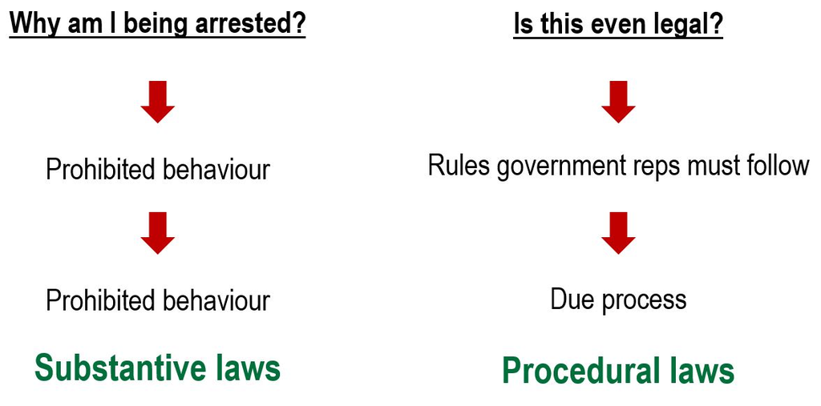

## Substance and procedure

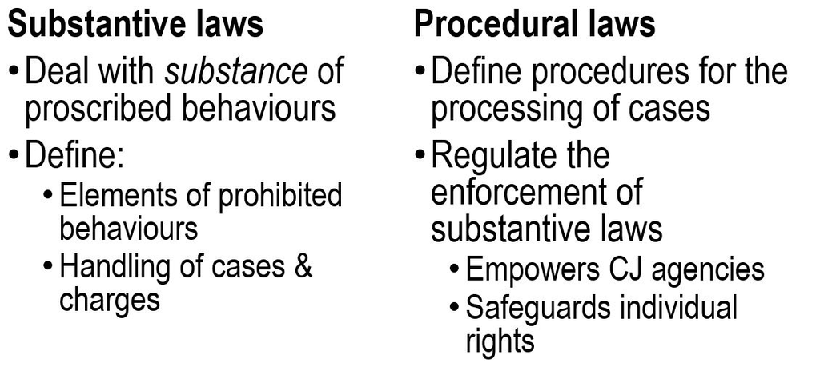

## In the realm of Canadian criminal law

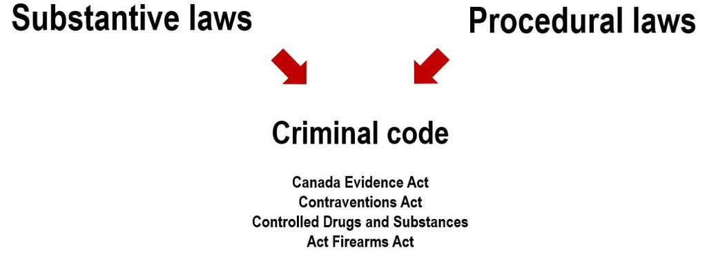

## The law of the land

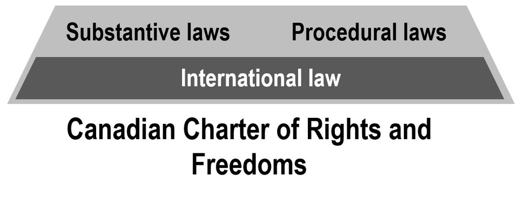

## Alignment example

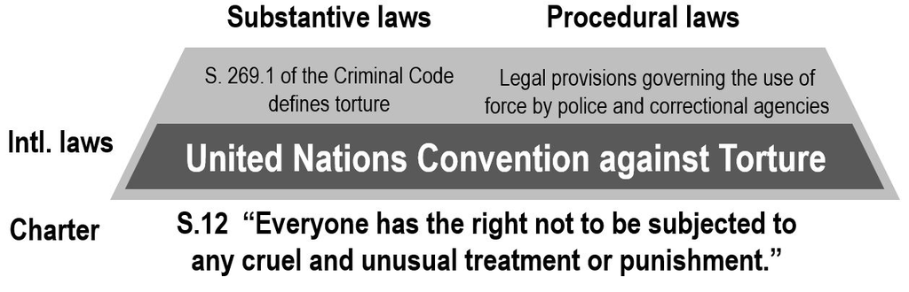

## Origins and changes in the law

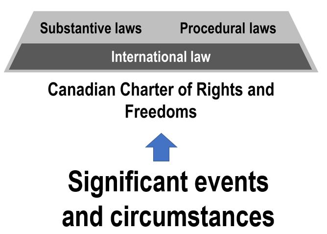

## Judge David Ashworth’s Ted Talk on drug courts

Identify references to changes in and features of substantive and procedural laws

[video not shown]

# Sources of law

## Sources of Canadian Law

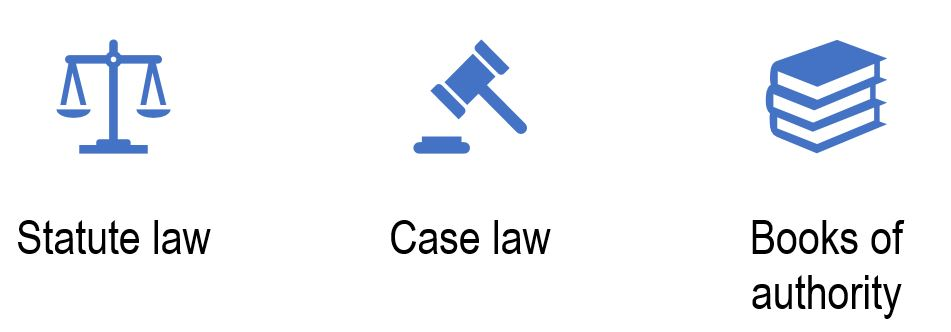

## Statute laws

- Written laws that prohibit or mandate certain acts
- Enacted by a legislative body, such as the Parliament of Canada
  - Debates
  - Public hearings
  - Analysis

## Case Law

- Established by previous court decisions and based on the rule of precedent
- Precedent: A judicial decision that may be used as a standard in subsequent similar cases
- Stare decisis: The principle by which higher courts set precedents that lower courts must follow

## Court hierarchy

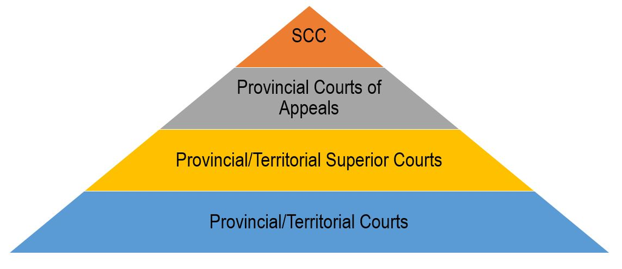

## Example: Disclosing HIV Status

- R. v. Cuerrier, [1998] 2 SCR 37
  - Non-disclosure of HIV status vitiates the consent of uninformed participants
  - Turned otherwise “consensual” sex into aggravated sexual assault
  - Ununiformed participants put at "significant risk of bodily harm“
- R. v. Mabior, [2012] 2 SCR 584
  - Consent not vitiated if risk is mitigated (condom + treatment)

## Supervised injection sites

Identify references to different sources of law

[video not shown]

# Criminalization of illegal drug use and distribution in Canada

## Exercise

- Read through the following section of this week’s reading assignment:
  - “The criminalization of illegal drug use and distribution: Taking account of the complexities of sources of law”
- Identify referenced:
  - Sources of law
  - Changes in substantive and procedural laws

# Important content

## Key concepts and terms

- Substantive law
- Procedural law
- Sources of law
- Case law
- Statute law
- Court hierarchy